# ggplot2

## Why learn ggplot2?

Base R can generate stunning plots . . . with time.

`ggplot2` gets you to pretty plots very quickly. Also:

- Consistent aesthetic.
- Plays well with `dplyr`.
- Systematic Syntax: "grammar of graphics".

## Grammar of Graphics

Theory of data graphics proposed by Leland Wilkinson. Each statistical graphic has four elements:

1. Data
2. Mapping between variables and aesthetics (e.g. color, shape, scale)
3. Geometric objects (e.g points, lines, polygons)
4. Statistical transformation (e.g. smoothing, binning)

## Two approaches to making a plot

1. `qplot`
2. `ggplot + geom`

We'll focus on `ggplot + geom` because it makes the grammar more transparent.

## Example: Diamond Data

## Diamond Data

Get acquainted with the data set.

```r
require(ggplot2)
?diamonds
dim(diamonds)
head(diamonds)
```

## Motivating question

What it the relationship between the carat of diamonds and their price, when you're comparing diamonds of the same cut quality?

Take a moment to sketch out (on paper | whiteboard) a visualization that yields insight into the question above.

## Before we get into plotting…

Let's subset our data so it is more manageable.

```r
library(ggplot2)
library(dplyr)
set.seed(42)
small <- diamonds %>% sample_n(1000)
```

What is the relationship between the carat of diamonds and their price, when you're comparing diamonds of the same cut quality?

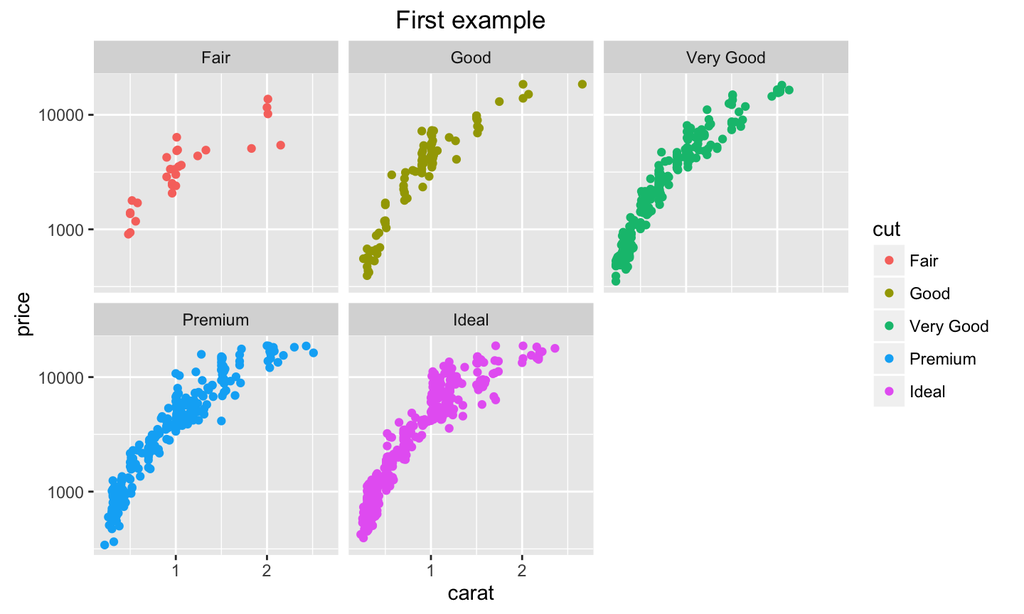

## A look at the code

```r
ggplot(small)
+ geom_point(aes(x = carat, y = price, colour = cut))
+ scale_y_log10()
+ facet_wrap(~cut)
+ ggtitle("First example")
```

The various graphical components are separate blocks that are added together to make the plot.

## Let's decompose that

1. Data: `ggplot(small)`
2. Layers: `geom_point(aes(x = carat, y = price, colour = cut))`
3. facets: `facet_wrap(~cut)`
4. scales: `scale_y_log10()`
5. more options: `ggtitle("First example")`

demo code

## Variations on syntax

```r
ggplot(small) + geom_point(aes(x = carat, y = price, colour = cut))
```

versus

```r
ggplot(small, aes(c = carat, y = price, colour = cut)) + geom_point()
```

## A subtlety to be aware of

Caveat - there is a difference between setting and mapping aesthetics.

1. Mapping dynamically links data to aesthetics through `aes()`.
2. Setting a parameter to a fixed value is done *outside* of `aes`.

Don't mix!

demo code

Take a look at the first few rows of the `CO2` dataset that is built-in to R.

1. Make a scatterplot of concentration versus uptake for this dataset.
2. Add color to indicate which plant is associated with each datapoint.
3. Connect the points with lines.
4. Add size to indicate the type.

## ggplot2 vs base

**Strengths** - Make beautiful graphics very fast. - Easy to update/modify plots. - Make highly customized plots very efficiently. - Plays great with `dplyr`.

**Weaknesses** - No 3d plotting or dynamic plots (see `ggvis`). - Can be difficult for unorthodox plots. - Slower processing time.

## Where to find these functions

First decide a geometry that is appropriate for the data type and the relationship you're aiming to show.

```
http://docs.ggplot2.org/
```

Once you settled on a geometry, you need to map data to aesthetics. You can also look for help.

```r
?geom_point
```